# R Notebook

```r
library(readxl)
library(tidyverse)
library(car)
Concrete_Data <- read_excel("C:/Users/HP DV6/Downloads/Concrete_Data.xls")
# Rename column name to make it easier to operate on.
Concrete_Data <- rename(Concrete_Data,
  concrete = `Concrete compressive strength(MPa, megapascals)`,
  cement = `Cement (component 1)(kg in a m^3 mixture)`,
  b_furnace = `Blast Furnace Slag (component 2)(kg in a m^3 mixture)`,
  water = `Water  (component 4)(kg in a m^3 mixture)`,
  superpl = `Superplasticizer (component 5)(kg in a m^3 mixture)`,
  c_aggregate = `Coarse Aggregate  (component 6)(kg in a m^3 mixture)`,
  f_aggregate = `Fine Aggregate (component 7)(kg in a m^3 mixture)`,
  age = `Age (day)`,
  fly_ash = `Fly Ash (component 3)(kg in a m^3 mixture)`


)
train <- Concrete_Data[1:900,]
test <- Concrete_Data[901:1030,]
```

Graphical analysis of concrete data set.

Examining bivariate relationship between dependent variables to determine if interaction effect exist.

```r
cor(Concrete_Data)
```

```
                 cement   b_furnace      fly_ash       water     superpl  c_aggregate f_aggregate
cement       1.00000000 -0.27519344 -0.397475440 -0.08154361  0.09277137 -0.109356039 -0.22272017
b_furnace   -0.27519344  1.00000000 -0.323569468  0.10728594  0.04337574 -0.283998230 -0.28159326
fly_ash     -0.39747544 -0.32356947  1.000000000 -0.25704400  0.37733956 -0.009976788  0.07907635
water       -0.08154361  0.10728594 -0.257043997  1.00000000 -0.65746444 -0.182311668 -0.45063498
superpl      0.09277137  0.04337574  0.377339559 -0.65746444  1.00000000 -0.266302755  0.22250149
c_aggregate -0.10935604 -0.28399823 -0.009976788 -0.18231167 -0.26630276  1.000000000 -0.17850575
f_aggregate -0.22272017 -0.28159326  0.079076351 -0.45063498  0.22250149 -0.178505755  1.00000000
age          0.08194726 -0.04424580 -0.154370165  0.27760443 -0.19271652 -0.003015507 -0.15609405
concrete     0.49783272  0.13482445 -0.105753348 -0.28961348  0.36610230 -0.164927821 -0.16724896
                     age   concrete
cement       0.081947264  0.4978327
b_furnace   -0.044245801  0.1348244
fly_ash     -0.154370165 -0.1057533
water        0.277604429 -0.2896135
superpl     -0.192716518  0.3661023
c_aggregate -0.003015507 -0.1649278
f_aggregate -0.156094049 -0.1672490
age          1.000000000  0.3288770
concrete     0.328876976  1.0000000
```

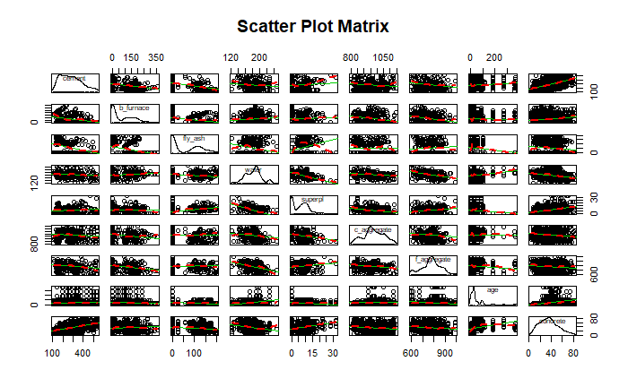

```r
scatterplotMatrix(Concrete_Data, spread=FALSE, smoother.args=list(lty=2),
main="Scatter Plot Matrix")
```

Fitting a muitlple linear regression on the data set.

```r
lm_fit <- lm(concrete ~ ., data = train)
summary(lm_fit)
```

```
Call:
lm(formula = concrete ~ ., data = train)

Residuals:
    Min      1Q  Median      3Q     Max
-28.596  -6.665   0.849   7.090  34.769

Coefficients:
             Estimate Std. Error t value Pr(>|t|)
(Intercept) -3.390738  29.311282  -0.116  0.90793
cement       0.110993   0.009559  11.612  < 2e-16 ***
b_furnace    0.094837   0.011159   8.499  < 2e-16 ***
fly_ash      0.086214   0.013920   6.193 8.98e-10 ***
water       -0.175662   0.044412  -3.955 8.25e-05 ***
superpl      0.311767   0.104489   2.984  0.00293 **
c_aggregate  0.013301   0.010350   1.285  0.19908
f_aggregate  0.010455   0.011924   0.877  0.38085
age          0.115364   0.005688  20.281  < 2e-16 ***
---
Signif. codes:  0 ‘***’ 0.001 ‘**’ 0.01 ‘*’ 0.05 ‘.’ 0.1 ‘ ’ 1

Residual standard error: 10.76 on 891 degrees of freedom
Multiple R-squared:  0.6127,    Adjusted R-squared:  0.6092
F-statistic: 176.2 on 8 and 891 DF,  p-value: < 2.2e-16
```

There is a relationship between the response and predicator variables with a F-statistic of 176.2 and a p-value of < 2.2e-16. Most of the predicator variables are statistically significant save two, c_aggregate and f_aggregate.Overall, this model accounts for 60.92% of concrete’s variance.

Diagnosing the model.

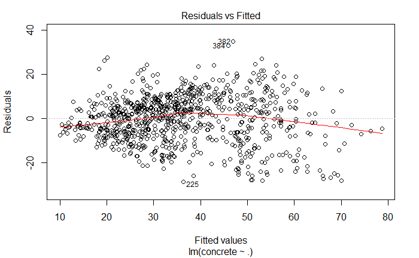

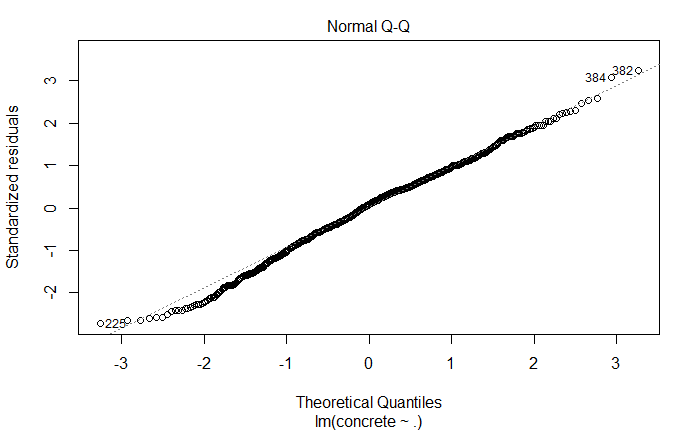

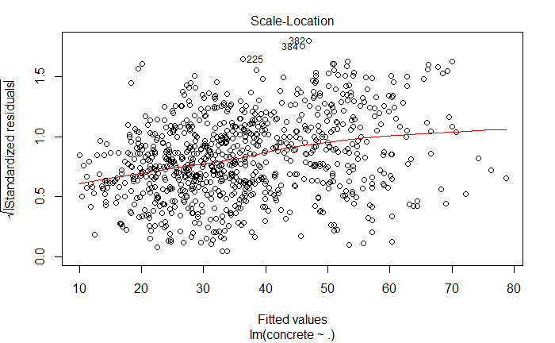

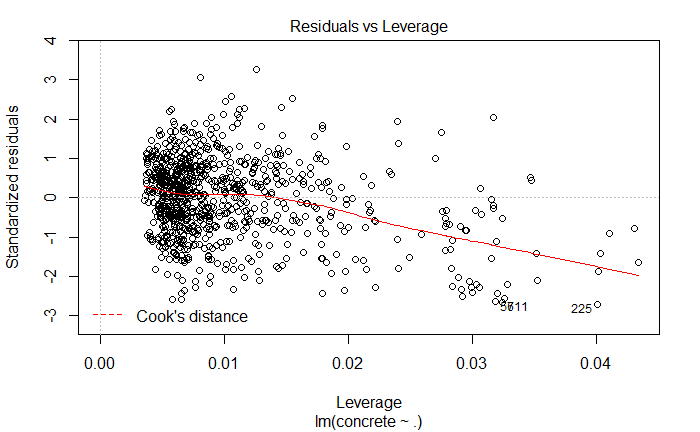

```r
plot(lm_fit)
```

The Residuals vs Fitted plot shows elements of heteroscedasticity. The plot also shows 382, 384 and 225 are outliers. The Residuals vs Leverage shows 225 ,711, and 55 have high leverages.

```r
train <- filter(train, !cement %in% c(315,516,212.52,305.3,189.6))
lm_fit2 <- lm(concrete~.-c_aggregate-f_aggregate, train)
summary(lm_fit2)
```

```
Call:
lm(formula = concrete ~ . - c_aggregate - f_aggregate, data = train)

Residuals:
    Min      1Q  Median      3Q     Max
-29.771  -6.622   0.981   7.030  32.924

Coefficients:
             Estimate Std. Error t value Pr(>|t|)
(Intercept) 27.818373   4.952071   5.618  2.6e-08 ***
cement       0.103219   0.004679  22.061  < 2e-16 ***
b_furnace    0.084665   0.005572  15.195  < 2e-16 ***
fly_ash      0.076602   0.008819   8.686  < 2e-16 ***
water       -0.210730   0.025044  -8.414  < 2e-16 ***
superpl      0.274275   0.095609   2.869  0.00422 **
age          0.113958   0.005635  20.223  < 2e-16 ***
---
Signif. codes:  0 ‘***’ 0.001 ‘**’ 0.01 ‘*’ 0.05 ‘.’ 0.1 ‘ ’ 1

Residual standard error: 10.7 on 881 degrees of freedom
Multiple R-squared:  0.6155,    Adjusted R-squared:  0.6129
F-statistic: 235.1 on 6 and 881 DF,  p-value: < 2.2e-16
```

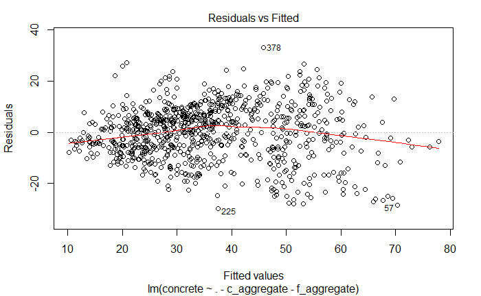

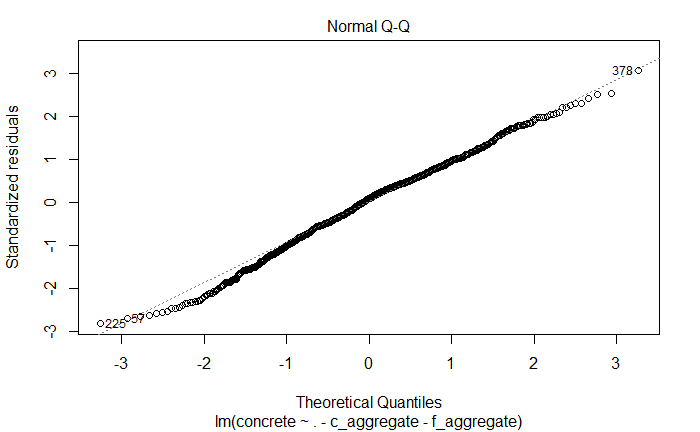

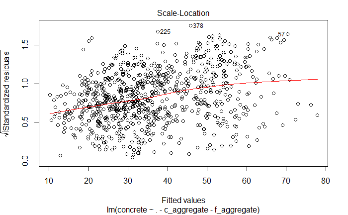

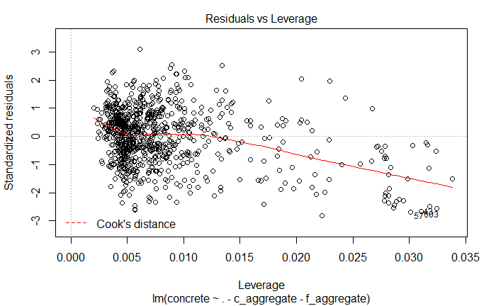

```r
plot(lm_fit2)
```

After removing outliers the model R-squared increased from 0.6092 to 0.6129, and the RSE reduces from 10.76 to 10.7.

Fitting interactions into the model.

```r
lm_fit3 <- lm(concrete~.-c_aggregate -f_aggregate + superpl : water    , train)
summary(lm_fit3)
```

```
Call:
lm(formula = concrete ~ . - c_aggregate - f_aggregate + superpl:water,
    data = train)

Residuals:
     Min       1Q   Median       3Q      Max
-30.2176  -6.3321   0.5695   7.1764  30.1684

Coefficients:
               Estimate Std. Error t value Pr(>|t|)
(Intercept)   42.554198   5.677898   7.495 1.62e-13 ***
cement         0.100766   0.004639  21.721  < 2e-16 ***
b_furnace      0.079259   0.005597  14.162  < 2e-16 ***
fly_ash        0.053509   0.009810   5.455 6.38e-08 ***
water         -0.284806   0.028670  -9.934  < 2e-16 ***
superpl       -2.372928   0.528795  -4.487 8.17e-06 ***
age            0.120365   0.005698  21.123  < 2e-16 ***
water:superpl  0.016709   0.003284   5.088 4.43e-07 ***
---
Signif. codes:  0 ‘***’ 0.001 ‘**’ 0.01 ‘*’ 0.05 ‘.’ 0.1 ‘ ’ 1

Residual standard error: 10.55 on 880 degrees of freedom
Multiple R-squared:  0.6265,    Adjusted R-squared:  0.6236
F-statistic: 210.9 on 7 and 880 DF,  p-value: < 2.2e-16
```

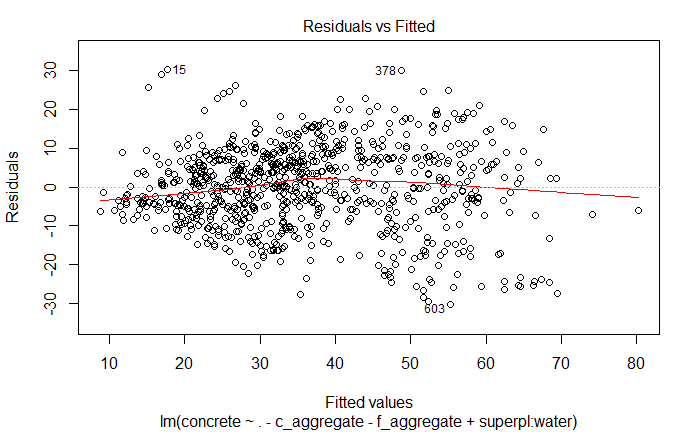

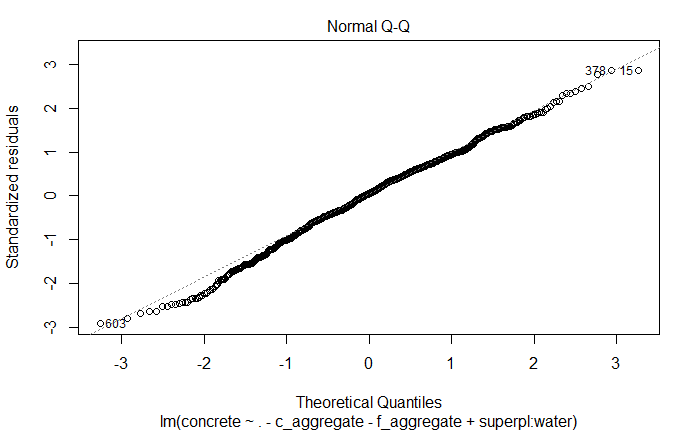

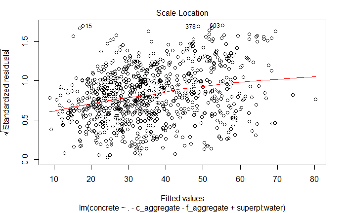

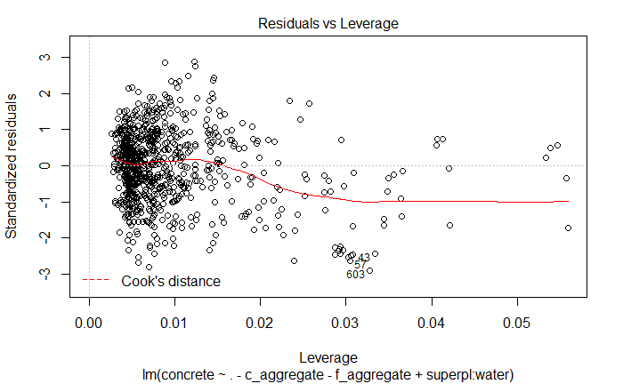

```r
plot(lm_fit3)
```

After fitting the interaction effect into the dataset. The model accounts for 62.36 % of the variance in concrete compressive strength.

Testing the model and compute the R^2 of the predicted values.

```r
predicted_values <- predict(lm_fit3, test)
predicted_values <- data.frame(predicted_values)
predicted_values <- cbind(predicted_values, test$concrete)
SSE <- sum((predicted_values$`test$concrete` - predicted_values$predicted_values  ) ^ 2)
SST  <- sum((predicted_values$`test$concrete` - mean(predicted_values$`test$concrete`)) ^ 2)
print(1 - SSE/ SST)
```

```
[1] 0.5640707
```

The linear model explained 56.40% of test data’s concrete varaince.